# Detecting Circadian Rhythmicity in DNA Methylation with CirBEM

# 1 Introduction

CirBEM is an R package for detecting circadian rhythmicity in DNA methylation data. DNA methylation beta values are bounded between 0 and 1 and often exhibit strong mean-variance dependence, making standard Gaussian cosinor models less well suited for modeling methylation dynamics. In addition, circadian methylation studies commonly involve repeated measurements from the same subjects, requiring methods that can account for within-subject correlation. Existing rhythmicity detection methods are often designed for approximately Gaussian gene-expression measurements or independent samples.

CirBEM addresses these issues by fitting cosinor-based beta regression models for methylation beta values. The model represents rhythmic methylation patterns using sine and cosine terms, while optional subject-specific random intercepts account for repeated measurements. To improve stability in genome-wide analyses, CirBEM also incorporates empirical Bayesian shrinkage of the beta-regression precision parameter.

This vignette demonstrates how to use CirBEM for:

1. Fitting fixed- and mixed-effect beta-regression cosinor models to methylation data.
2. Detecting rhythmic CpG sites and ranking results.
3. Visualizing fitted circadian methylation patterns.

# 2 Installation

```r
if (!require("BiocManager", quietly = TRUE))
    install.packages("BiocManager")
BiocManager::install("cirBEM")
```

# 3 Data Preparation

CirBEM expects a `SummarizedExperiment` with: 1. An assay containing methylation beta values (CpGs x samples); 2.`colData` with at minimum a numeric time column (in hours) 3.Optionally, a subject identifier column for repeated measures.

The package includes example data (3000 CpGs, 8 subjects, 6 timepoints):

```r
library(cirBEM)
library(SummarizedExperiment)

# Load bundled example data
example <- readRDS(system.file("extdata", "example_data.rds",
    package = "cirBEM"))
se <- example$se
se
```

```
#> class: SummarizedExperiment
#> dim: 3000 48
#> metadata(0):
#> assays(1): beta
#> rownames(3000): cg00001 cg00002 ... cg02999 cg03000
#> rowData names(0):
#> colnames(48): S1_T0 S1_T4 ... S8_T16 S8_T20
#> colData names(3): time subject Sample_Name
```

For a fast vignette build, the fitted examples below use a small subset of the bundled dataset.

```r
se_demo <- se[seq_len(100), ]
```

# 4 Fixed-Effects Analysis

A fixed-effects model uses all samples and does not include subject-specific random intercepts. For repeated-measures data, this treats observations as independent and can be useful as a simple baseline model.

```r
se_fixed <- fitCosinor(se_demo,
    time_col = "time",
    mode = "fixed",
    eb_shrink = TRUE,
    min_cpgs = 50,
    BPPARAM = BiocParallel::SerialParam(),
    verbose = TRUE
)
se_fixed
```

[output not shown]

# 5 Longitudinal Analysis (Mixed-Effects)

When subjects have repeated measurements across time:

```r
se_demo <- fitCosinor(se_demo,
    time_col = "time",
    subject_col = "subject",
    eb_shrink = TRUE,
    min_cpgs = 50,
    BPPARAM = BiocParallel::SerialParam(),
    verbose = TRUE
)
```

# 6 Interpreting Results

The output of `fitCosinor()` is the input `SummarizedExperiment` object with model results appended to `rowData()` and analysis-level information stored in `metadata()`.

Specifically:

- `rowData(se_demo)` contains per-CpG model estimates, circadian summary statistics, hypothesis test results, adjusted p-values, and convergence indicators.
- `metadata(se_demo)$cirBEM` contains analysis-level information, including the model design, empirical Bayes prior estimates, test settings, and fitting summary.

## 6.1 Circadian parameter estimates

All per-CpG model results are available from `rowData(se_demo)`:

```r
res <- rowData(se_demo)
head(res)
```

```
#> DataFrame with 6 rows and 11 columns
#>                b0     b_sin     b_cos amplitude_response     phase
#>         <numeric> <numeric> <numeric>          <numeric> <numeric>
#> cg00001  0.869900  0.212566  0.386243          0.0909269   22.0783
#> cg00002  0.496719  0.396694  0.184526          0.1008204   19.6631
#> cg00003  0.690321  0.152833  0.331238          0.0805366   22.3488
#> cg00004 -1.100572  0.261746  0.294583          0.0733876   21.2252
#> cg00005  0.580505  0.291745  0.120900          0.0721993   19.5006
#> cg00006 -0.482334  0.407810  0.416019          0.1335875   21.0381
#>         mesor_response statistic        df      pvalue        padj converged
#>              <numeric> <numeric> <numeric>   <numeric>   <numeric> <logical>
#> cg00001       0.700732  20.84592         2 2.97417e-05 5.31102e-05      TRUE
#> cg00002       0.618231  22.12338         2 1.57025e-05 3.48267e-05      TRUE
#> cg00003       0.663912  19.03524         2 7.35446e-05 1.20565e-04      TRUE
#> cg00004       0.255069  21.80257         2 1.84346e-05 3.76216e-05      TRUE
#> cg00005       0.639701   5.53989         2 6.26654e-02 6.39443e-02      TRUE
#> cg00006       0.387330  29.80596         2 3.37068e-07 1.46551e-06      TRUE
```

In mixed-effects mode, response-scale summaries are reported as population-average quantities. That is, the fitted methylation curve is averaged over the subject-specific random-intercept distribution, rather than evaluated at a random effect of zero. This distinction is important because the inverse logit transformation is nonlinear.

## 6.2 Top-ranked CpG sites

The function `topCpGs()` returns the top-ranked CpG sites according to the rhythmicity test p-value or adjusted p-value, depending on the available result columns.

```r
topCpGs(se_demo, n = 10)
```

```
#> DataFrame with 10 rows and 6 columns
#>            cpg amplitude_response     phase mesor_response      pvalue
#>    <character>          <numeric> <numeric>      <numeric>   <numeric>
#> 1      cg00061          0.1689117   21.2832       0.368239 8.88674e-11
#> 2      cg00012          0.1261289   21.6629       0.460262 2.68025e-10
#> 3      cg00038          0.1596501   20.7961       0.603861 1.17203e-09
#> 4      cg00097          0.1064495   22.5163       0.700049 1.75645e-09
#> 5      cg00046          0.1626827   20.7728       0.475532 3.15132e-09
#> 6      cg00031          0.1531364   21.0095       0.539464 3.31245e-09
#> 7      cg00069          0.1618239   20.4107       0.625019 8.21461e-09
#> 8      cg00055          0.1419123   20.6163       0.400892 1.04817e-08
#> 9      cg00034          0.1681231   22.5679       0.544708 2.01653e-08
#> 10     cg00094          0.0970749   22.9446       0.599729 2.58505e-08
#>           padj
#>      <numeric>
#> 1  8.88674e-09
#> 2  1.34012e-08
#> 3  3.90676e-08
#> 4  4.39113e-08
#> 5  5.52074e-08
#> 6  5.52074e-08
#> 7  1.17352e-07
#> 8  1.31021e-07
#> 9  2.24059e-07
#> 10 2.58505e-07
```

# 7 Visualization

The fitted circadian methylation pattern can be visualized using `plotCosinorFit()`. By default, the function displays fitted 24-hour cosinor curves for the top-ranked CpG sites.

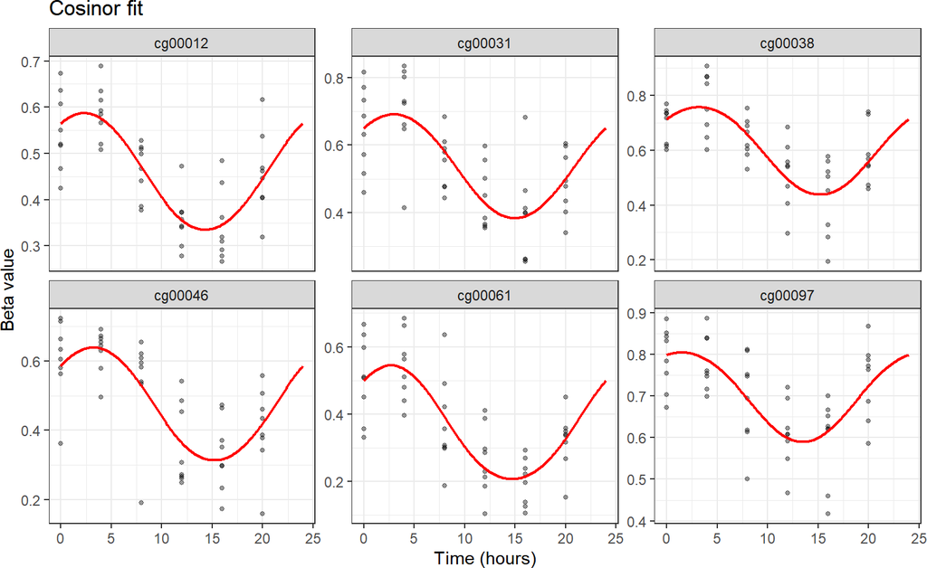

```r
plotCosinorFit(se_demo)
```